# Assigment3

Create two groups of clusters, the answers to the questions and regions where people grew up. Then create a visualization that shows the overlap between the two groups of clusters.

Code Book:

Duration (in seconds) Q1 - First Name Q2 - Last Name Q3 - Have you ever owned a cat? Q4 - Do you pronounce “gif”, with a J (j-iff) or a G (g-iff)? Q5 - How many months have you lived in New York City? Q6 - How many siblings (brothers/sisters) do you have? Q7 - How many times do you play sport each week? Q8 - How many miles do you travel from home to TC? Q9 - Estimate how many of your friends own Android phones Q10 - How many movies have you seen in the cinema this year? Q11 - How many classes are you taking this semester? Q12 - How many states have you visited in the US? Q13 - What city/town did you grow up in? Q14 - What state/province did you grow up in? Q15 - What country did you grow up in?

```r
t1<-read.csv("cluster-class-data.csv")

t2<-dplyr::select(t1, 4:13)
t3 <- na.omit(t2)

v1<-ifelse(t3$QID3 == "Yes", 1,0)
v2<-ifelse(t3$QID4 == "j-iff", 1,0)

t4<-dplyr::select(t3, 3:10)

t5 <- data.frame(v1, v2, t4)
t6<-scale(t5)

fit1 <- kmeans(t6, 2)


fit1$cluster
```

```
##  1  2  3  4  5  6  7  8  9 10 11 12 13 14 15 16 17 18 19 20 21 22
##  1  2  2  2  2  2  2  1  1  2  1  1  2  2  2  2  2  2  1  1  1  2
```

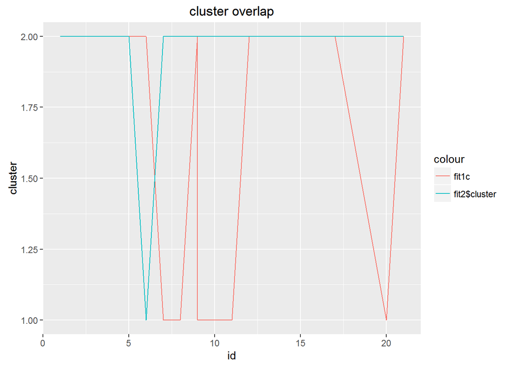

```r
t7 <- data.frame(t6, fit1$cluster)



 s1 <- dplyr::select(t1, 14:16)

 s2<-na.omit(s1)

lat<-as.data.frame(c(37.57,42.29,31.23,22.54,36.65,-33.02,39.14,35.09,24.47,30.44,29.87,22.54,28.70,40.71,23.02,21.31,39.90,41.14,39.96,40.89,41.43))

lon<-as.data.frame(c(126.98,-71.29,121.47,114.06,117.12,-77.55,-77.72,-92.44,118.09,-84.28,121.54,114.06,77.10,-74.01,113.75,-157.86,116.41,-73.36,-82.99,-74.48,-74.04))

s2<-cbind(lat,lon)

s2<-scale(s2)
fit2 <- kmeans(s2, 2)
s3<- data.frame(s2, fit2$cluster)
names(s3)<-c("lat","lon","value")
id<-c(1,2,3,4,5,6,7,8,9,10,11,12,13,14,15,16,17,8,9,20,21)
id<-as.data.frame(id)

fit1c<-as.data.frame(fit1$cluster)

fit1c<-fit1c[2:22,]

total<-cbind(id, fit1c, fit2$cluster)

library(ggplot2)
ll<-ggplot(total, aes(id)) +
  geom_line(aes(y = fit1c, colour = "fit1c")) +
  geom_line(aes(y = fit2$cluster, colour = "fit2$cluster"))+
ggtitle("cluster overlap") +
  labs(x="id",y="cluster")
ll
```